# Modelos lineales

Regresión y factoriales (ANOVA y ANCOVA)

## Introducción

- Definición
- Tipos
- Supuestos
- Flujo de trabajo

## Definición

Relación lineal entre dos o más variables, dependiendo una (variable dependiente) de la(s) otra(s) (variable(s) explicativa(s))

Modelo matemático lineal: y = 2x o y = 3 - 2x

### Objetivos

1. Descripción de la relación
2. Inferencia, o generalización de los resultados
3. Predicciones

## Tipos

Variable dependiente: siempre cuantitativa

Variables explicativas:

- Cuantitativas: modelos de regresión (simple o múltiple)
- Cualitativas o categóricas: ANOVA
- Cuantitativas y categóricas: ANCOVA

## Supuestos del modelo

1. Independencia
2. Linealidad
3. Normalidad
4. Homocedasticidad

## Flujo de trabajo

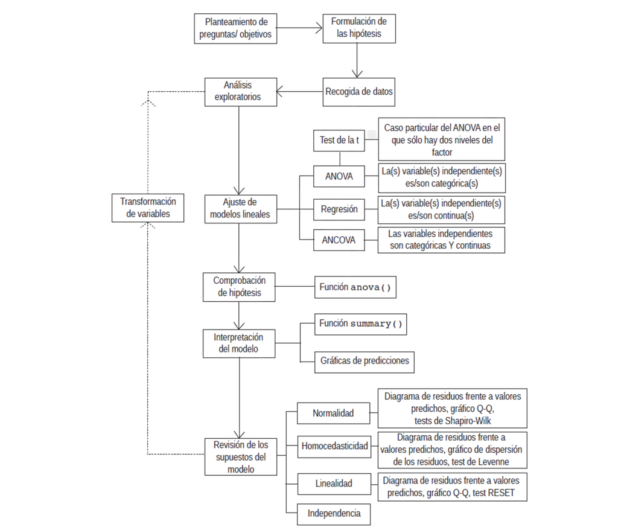

Pasos a seguir análisis de datos con modelos lineales (Cayuela y de la Cruz, 2022)

### Formular problema correctamente

1. Comprender problema y contexto
2. Comprender objetivo del estudio
3. Plantear problema en términos estadísticos
4. Entender bien los datos

## Regresión simple y regresión múltiple

### Estructura

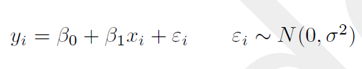

Ecuación regresión

*β<sub>0</sub>*: ordenada en el origen

*β<sub>1</sub>*: pendiente

*Ɛ<sub>i</sub>*: residuos

### Ajuste modelo lineal

Función lm(y ~ x)

### Ejemplo

Pregunta: Masa corporal especies pingüinos y cómo esta es influenciada por la longitud de la aleta de los pingüinos

Hipótesis

*H<sub>0</sub>* (hipótesis nula): no existe relación entre la masa corporal de los pingüinos y la longitud de sus aletas

*H<sub>0</sub> : β<sub>1</sub> = 0*

*H<sub>1</sub>* (hipótesis alternativa): pendienta de la recta que relaciona masa corporal con longitud aleta es distinta de cero

*H<sub>0</sub> : β<sub>1</sub> ≠ 0*

#### 1. Leer los datos en R y explorar gráficamente la relación entre las variables

```r
library(palmerpenguins)
data(penguins)
head(penguins)
```

```
# A tibble: 6 × 8
  species island    bill_length_mm bill_depth_mm flipper_length_mm body_mass_g
  <fct>   <fct>              <dbl>         <dbl>             <int>       <int>
1 Adelie  Torgersen           39.1          18.7               181        3750
2 Adelie  Torgersen           39.5          17.4               186        3800
3 Adelie  Torgersen           40.3          18                 195        3250
4 Adelie  Torgersen           NA            NA                  NA          NA
5 Adelie  Torgersen           36.7          19.3               193        3450
6 Adelie  Torgersen           39.3          20.6               190        3650
# ℹ 2 more variables: sex <fct>, year <int>
```

```r
library(ggplot2)
ggplot(data = penguins, aes(x = flipper_length_mm, y = body_mass_g)) +
  geom_point(color = "blue", size = 3) +
  labs(x = "Longitud aleta (mm)",
       y = "Masa corporal (g)",
      title = "Relación entre masa corporal y longitud aleta "
  ) +
  theme_minimal()
```

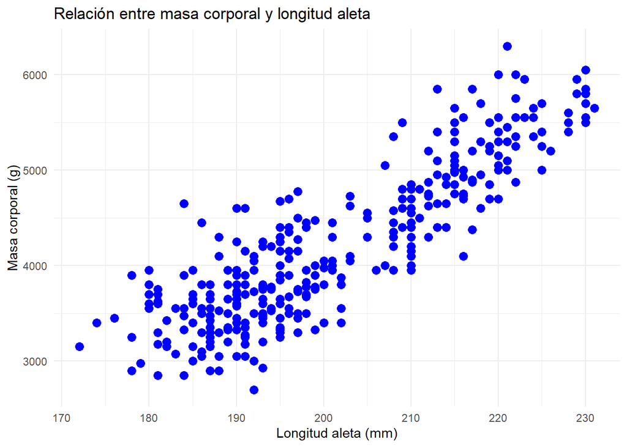

#### 2. Ajuste modelo de regresión

```r
lm_reg1 <- lm(body_mass_g ~ flipper_length_mm, data = penguins)
```

#### 3. Variación explicada por el modelo y resolución hipótesis

###### Tabla del análisis de la varianza

```r
anova(lm_reg1)
```

```
Analysis of Variance Table

Response: body_mass_g
                   Df    Sum Sq   Mean Sq F value    Pr(>F)
flipper_length_mm   1 166452902 166452902  1070.7 < 2.2e-16 ***
Residuals         340  52854796    155455
---
Signif. codes:  0 '***' 0.001 '**' 0.01 '*' 0.05 '.' 0.1 ' ' 1
```

Suma de cuadrados: variabilidad de la variable *y*

Coeficiente de determinación (R<sup>2</sup>): bondad de ajuste del modelo (0-1)

#### 4. Interpretación del modelo

```r
summary(lm_reg1)
```

```
Call:
lm(formula = body_mass_g ~ flipper_length_mm, data = penguins)

Residuals:
     Min       1Q   Median       3Q      Max
-1058.80  -259.27   -26.88   247.33  1288.69

Coefficients:
                   Estimate Std. Error t value Pr(>|t|)
(Intercept)       -5780.831    305.815  -18.90   <2e-16 ***
flipper_length_mm    49.686      1.518   32.72   <2e-16 ***
---
Signif. codes:  0 '***' 0.001 '**' 0.01 '*' 0.05 '.' 0.1 ' ' 1

Residual standard error: 394.3 on 340 degrees of freedom
  (2 observations deleted due to missingness)
Multiple R-squared:  0.759, Adjusted R-squared:  0.7583
F-statistic:  1071 on 1 and 340 DF,  p-value: < 2.2e-16
```

*y = 49.686x - 5780.831*

Fiabilidad estimadores para predecir

R<sup>2</sup> y R<sup>2</sup> ajustado

#### 5. Predicciones con el modelo

```r
library(broom)
library(tidyverse)
library(dplyr)
preds <- augment(lm_reg1, type.predict = "response", se_fit = TRUE)
preds <- preds %>%
  mutate(lower = .fitted - 1.96 * .se.fit,upper = .fitted + 1.96 * .se.fit)

ggplot(data = preds, aes(x = flipper_length_mm, y = body_mass_g)) +
  geom_point(color = "blue", size = 2) +
  geom_line(aes(y = .fitted)) +
  geom_ribbon(aes(ymin = lower, ymax = upper), alpha = 0.2) +
  labs(x = "Longitud aleta (mm)",
       y = "Masa corporal (g)",
      title = "Predicciones modelo de regresión"
  ) +
  theme_minimal()
```

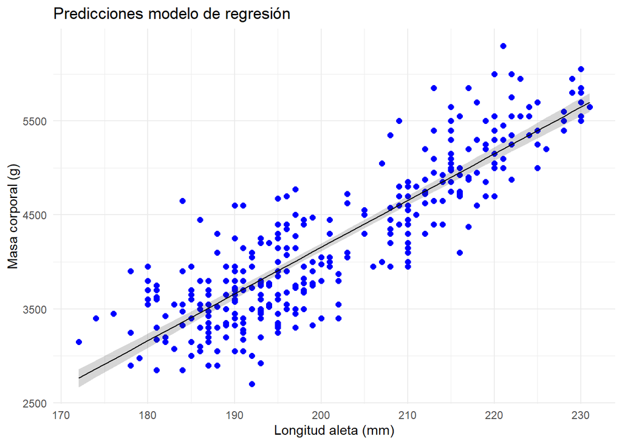

#### 6. Revisión supuestos del modelo

Supuestos de linealidad, normalidad y homocedasticidad

```r
par(mfrow=c(2,2))
plot(lm_reg1)
```

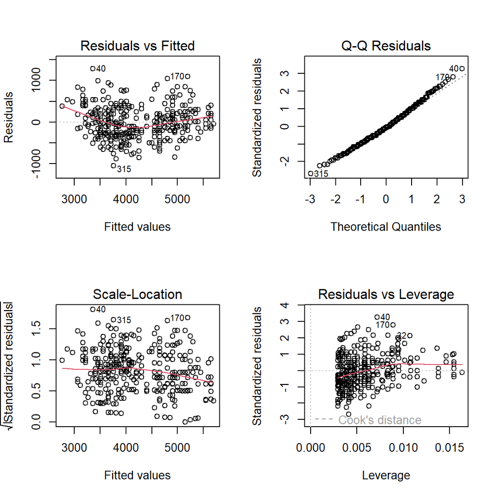

Normalidad:

```r
shapiro.test(residuals(lm_reg1))
```

```
    Shapiro-Wilk normality test

data:  residuals(lm_reg1)
W = 0.99301, p-value = 0.1123
```

Linealidad:

```r
library(lmtest)
resettest(lm_reg1)
```

```
    RESET test

data:  lm_reg1
RESET = 15.998, df1 = 2, df2 = 338, p-value = 2.3e-07
```

Homocedasticidad:

```r
library(car)
ncvTest(lm_reg1)
```

```
Non-constant Variance Score Test
Variance formula: ~ fitted.values
Chisquare = 2.177953, Df = 1, p = 0.14
```

No se cumplen supuestos del modelo: transformación variables (logarítmica, raíz cuadrada, Box-Cox, log-log, etc.)

### Regresión múltiple

*y<sub>i</sub> = β<sub>0</sub> + β<sub>1</sub>x<sub>1</sub> + … + β<sub>1</sub>x<sub>n</sub> + Ɛ<sub>i</sub>*

*Ɛ<sub>i</sub> ~N(0,σ<sup>2</sup>)*

Suma de cuadrados tipo I o III

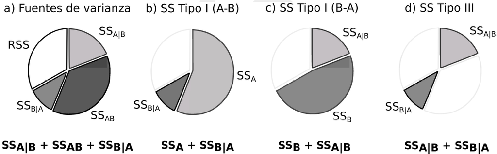

Suma de cuadrados: tipos (Cayuela y de la Cruz, 2022